# My Ultramarathon Race Times

Garret Christensen

September 21, 2016

# Summary

I’m just trying to learn some ML using my ultramarathon race times.

```r
data<-read.csv(file="racedata.csv", head=TRUE)
data$Climbing=as.numeric(data$Climbing)
head(data)
```

[output not shown]

To date, I have run 72 races, 17 of which were 100 or more miles long. This doesn’t include a handful of off-trail or orienteering races. It does include (boring) paved marathons, of which I have run 10.

The average distance of my races is 56 miles. The average time elapsed is 13.95 hours.

# Distance vs. Time

First, I’ll plot time versus distance and fit a univariate regression line.

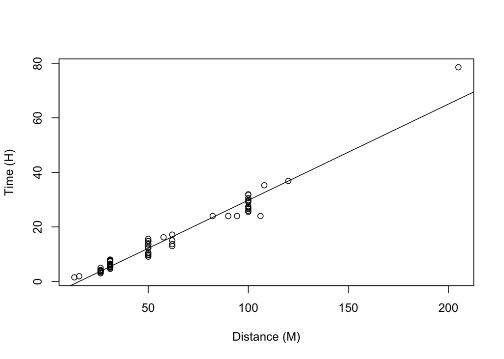

```r
data$Time=data$Hours+data$Minutes/60
mod1<-lm(data$Time~data$Distance)
plot(data$Time~data$Distance, xlab="Distance (M)", ylab="Time (H)")
abline(mod1)
```

Eyeballing that looks like linear regression makes a lot of sense, but I’ll see if a quadratic polynomial does any better

```r
data$DistanceSQ=data$Distance^2
mod2<-lm(data$Time~data$Distance+data$DistanceSQ)
library(stargazer)
stargazer(mod1, mod2, se=list(NULL, NULL), type="html", out="stargazerout.html", title="Linear and Quadratic Models", align=TRUE, column.labels=c("Linear","Quadratic"))
```

**Linear and Quadratic Models**

|  | *Dependent variable:* |  |
| --- | --- | --- |
|  | Time |  |
|  | Linear | Quadratic |
|  | (1) | (2) |
| Distance | 0.353*** | 0.221*** |
|  | (0.009) | (0.019) |
| DistanceSQ |  | 0.001*** |
|  |  | (0.0001) |
| Constant | -5.470*** | -1.677** |
|  | (0.554) | (0.678) |
| Observations | 71 | 71 |
| R<sup>2</sup> | 0.961 | 0.978 |
| Adjusted R<sup>2</sup> | 0.961 | 0.977 |
| Residual Std. Error | 2.490 (df = 69) | 1.895 (df = 68) |
| F Statistic | 1,717.000*** (df = 1; 69) | 1,508.000*** (df = 2; 68) |
| *Note:* | p<0.1; p<0.05; p<0.01 |  |

Maybe a tiny bit. But what does the linear model say about my (slow) speed? The coefficient on distance is 0.3527. Which means on average I’m running 2.8355 miles per hour, or 21.16-minute miles. Jeebus, I am slow.

# More Predictors

The R^2 with just one regression is pretty high, 0.9614. Can I do better than that with more variables? Probably not, but let’s see. The variables I’ve been able to gather are the following:

```r
colnames(data)
```

```
##  [1] "RaceID"     "Name"       "Distance"   "Hours"      "Minutes"
##  [6] "Trail"      "Place"      "Rank"       "WinnerH"    "WinnerM"
## [11] "Climbing"   "Finishers"  "Starters"   "Time"       "DistanceSQ"
```

I think amount of vertical climbing definitely makes a big difference. Trail races tend to be slower than pavement, and the number of finishers might make me more competitive and run faster. Unfortunately I don’t have data for these variables on all the races.

```r
mod3<-lm(Time~Distance+DistanceSQ+Climbing, data=data)
mod4<-lm(Time~Distance+DistanceSQ+Climbing+Trail+Finishers, data=data)
stargazer(mod1, mod2, mod3, mod4, se=list(NULL, NULL, NULL, NULL), type="html", out="stargazerout2.html", title="Multivariate Linear Models", align=TRUE, column.labels=c("Linear","Quadratic", "Climbing", "All"))
```

**Multivariate Linear Models**

|  | *Dependent variable:* |  |  |  |
| --- | --- | --- | --- | --- |
|  | Time |  | Time |  |
|  | Linear | Quadratic | Climbing | All |
|  | (1) | (2) | (3) | (4) |
| Distance | 0.353*** | 0.221*** |  |  |
|  | (0.009) | (0.019) |  |  |
| DistanceSQ |  | 0.001*** |  |  |
|  |  | (0.0001) |  |  |
| Distance |  |  | 0.223*** | 0.225*** |
|  |  |  | (0.019) | (0.034) |
| DistanceSQ |  |  | 0.001*** | 0.001*** |
|  |  |  | (0.0001) | (0.0002) |
| Climbing |  |  | -0.024 | 0.020 |
|  |  |  | (0.022) | (0.044) |
| Trail |  |  |  | 0.134 |
|  |  |  |  | (5.120) |
| Finishers |  |  |  | -0.00005 |
|  |  |  |  | (0.001) |
| Constant | -5.470*** | -1.677** | -1.552** | -2.979 |
|  | (0.554) | (0.678) | (0.687) | (5.440) |
| Observations | 71 | 71 | 71 | 33 |
| R<sup>2</sup> | 0.961 | 0.978 | 0.978 | 0.982 |
| Adjusted R<sup>2</sup> | 0.961 | 0.977 | 0.977 | 0.978 |
| Residual Std. Error | 2.490 (df = 69) | 1.895 (df = 68) | 1.893 (df = 67) | 2.241 (df = 27) |
| F Statistic | 1,717.000*** (df = 1; 69) | 1,508.000*** (df = 2; 68) | 1,008.000*** (df = 3; 67) | 291.800*** (df = 5; 27) |
| *Note:* | p<0.1; p<0.05; p<0.01 |  |  |  |

OK, now first of all, the intercept should be zero, but I know it won’t be.

Second, why the hell is the coefficient on climbing negative? And how can I still have 71 obervations in the regression when I definitely don’t have all the Climbing observations? And why do the Distances appear on different lines? That’s annoying.